# SVM project

Anthony Ponce

9/27/2019

# 1 Introduction

This is an implementation of a support vector machine designed to identify short-term stock price changes, based on previous stock parameters: open, low, high, close, volume. This might be useful for day trades

## 1.1 Stock selected for this exercise:

Nintendo recently announced a new console at a more affordable price for children. I figured stock activity would increase.

picture of the stock volume

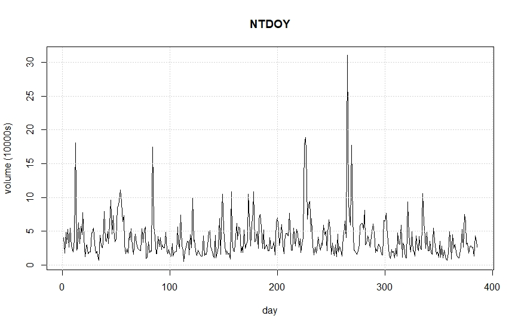

picture of the stock price

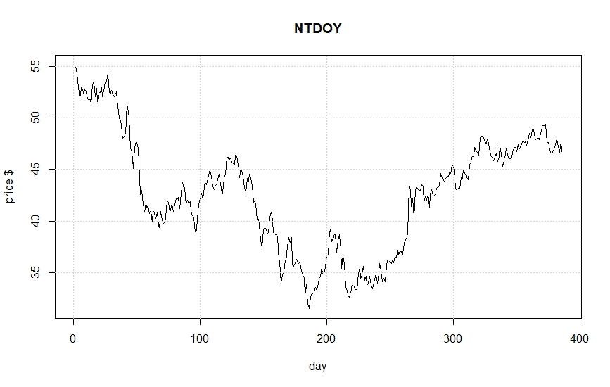

## 1.2 get data:

```r
NTDOYData = read.csv('NintendoStockChange.csv')
View(NTDOYData)
```

Names of the variables in the data set: price.open, price.high, price.low, price.close, volume, price.adjusted, ref.date’ ticker’ ret.adjusted.prices, ret.closing.prices’ pctChange. changeCategory

## 1.3 set up data frame

```r
    NTDOYDataFrame = data.frame(open=NTDOYData$price.open,        high=NTDOYData$price.high,  low=NTDOYData$price.low, close=NTDOYData$price.close,volume= NTDOYData$volume/10000,
      change = NTDOYData$changeCategory )
# look at top and bottom..
head(NTDOYDataFrame)
```

```
##    open  high   low close volume change
## 1 54.46 54.83 54.22 54.79  17.84   DOWN
## 2 53.18 53.68 52.61 53.63  47.90 STABLE
## 3 53.17 53.45 53.00 53.03  31.19 STABLE
## 4 52.74 52.99 51.30 51.78  52.94 STABLE
## 5 52.73 53.50 52.73 52.91  25.81 STABLE
## 6 52.75 52.83 52.30 52.73  54.51 STABLE
```

```r
tail(NTDOYDataFrame)
```

```
##      open  high   low close volume change
## 368 47.98 48.49 47.98 48.43  10.69 STABLE
## 369 49.12 49.12 48.72 49.11  22.11   DOWN
## 370 49.30 49.44 49.20 49.24  26.14   DOWN
## 371 49.38 49.90 49.15 49.26  52.63   DOWN
## 372 49.20 49.45 49.07 49.40  26.56   DOWN
## 373 48.91 49.20 47.31 47.60  74.61 STABLE
```

```r
remove(NTDOYData)
```

```r
levels(NTDOYDataFrame$change)
```

```
## [1] "DOWN"   "STABLE" "UP"
```

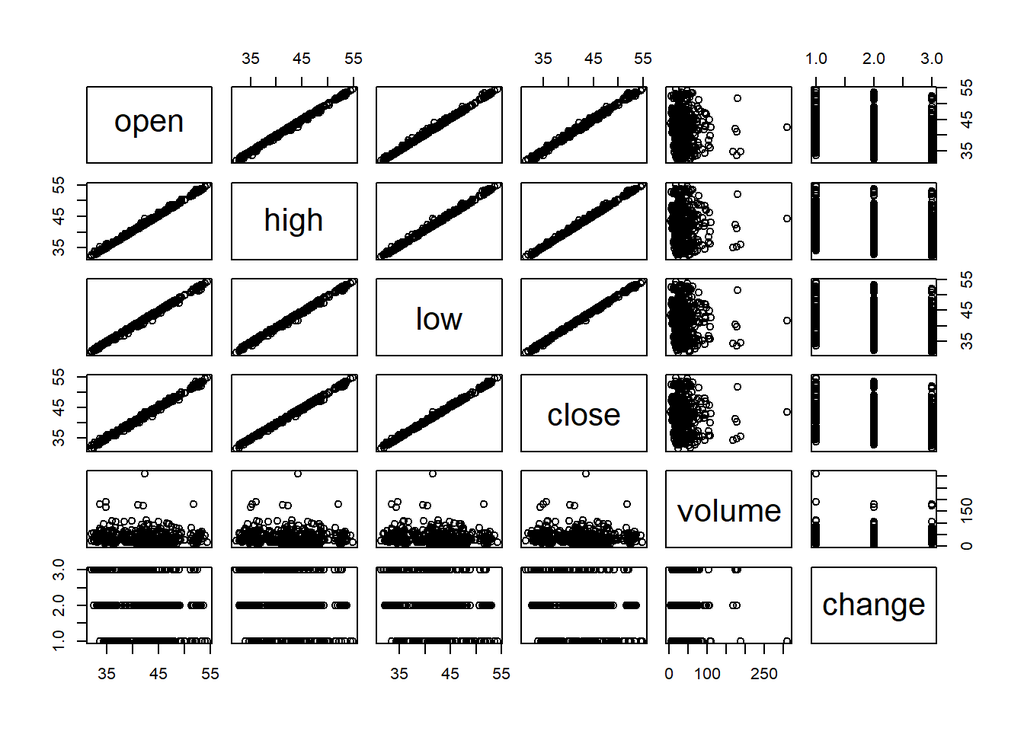

```r
plot(NTDOYDataFrame)
```

## 1.4 classification model, categorical response

### 1.4.1 traditional interface:

```r
x <- subset(NTDOYDataFrame[1:366,], select = -change)
y <- NTDOYDataFrame[1:366,]$change
model1 <- svm(x, y)
#model1 is all the data
print(model1)
```

```
##
## Call:
## svm.default(x = x, y = y)
##
##
## Parameters:
##    SVM-Type:  C-classification
##  SVM-Kernel:  radial
##        cost:  1
##
## Number of Support Vectors:  305
```

```r
summary(model1)
```

```
##
## Call:
## svm.default(x = x, y = y)
##
##
## Parameters:
##    SVM-Type:  C-classification
##  SVM-Kernel:  radial
##        cost:  1
##
## Number of Support Vectors:  305
##
##  ( 89 130 86 )
##
##
## Number of Classes:  3
##
## Levels:
##  DOWN STABLE UP
```

## 1.5 how well did the model fit?

```r
pred <- predict(model1, x)
# Check accuracy:
table(pred, y)
```

```
##         y
## pred     DOWN STABLE  UP
##   DOWN      8      2   2
##   STABLE   74    170  57
##   UP        7     18  28
```

## 1.6 decision values

```r
# compute decision values and probabilities:
pred <- predict(model1, x, decision.values = TRUE)
attr(pred, "decision.values")[1:6,]
```

```
##   DOWN/STABLE   DOWN/UP STABLE/UP
## 1  -0.9900553 1.0001702 0.9766633
## 2  -0.9984522 1.0039802 1.0028752
## 3  -1.0034016 1.0143785 1.0011919
## 4  -1.0069961 0.9849099 1.0030139
## 5  -1.0026298 1.0128613 1.0007113
## 6  -0.9976796 0.9954351 1.0081349
```

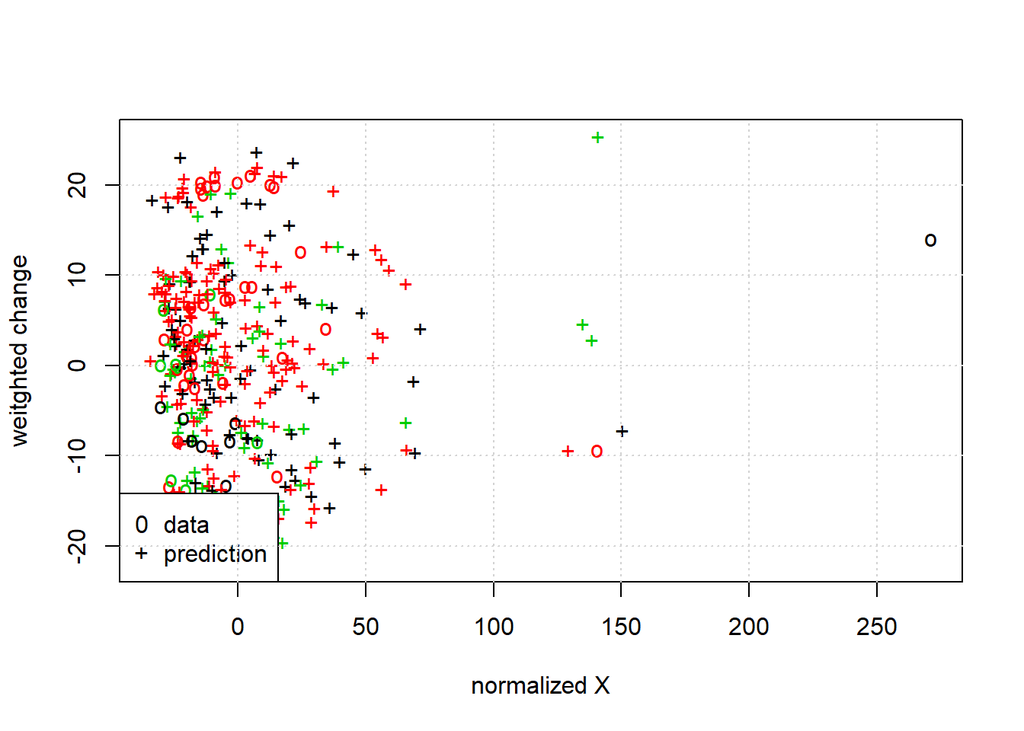

```r
# visualize (classes by color, SV by crosses):
plot(cmdscale(dist(NTDOYDataFrame[,-6])),
     col = as.integer(NTDOYDataFrame[,6]),xlab="normalized X", ylab = "weitghted change",
     pch = c("o","+")[1:150 %in% model1$index + 1])
legend('bottomleft',c('data','prediction'),pch=c('0','+'))
grid()
```

# 2 train and test sets:

```r
pctTrain=0.75  # use about 70% of the data
nObs = length(x[,1])
nObs = 366
nTrain = round(pctTrain*nObs,0)
# next line take data in order
#TrainSetIndex = 1:nTrain
# These lines take a random sample
scramble = sample(1:nObs)
TrainSetIndex = scramble[1:nTrain]
TestSetIndex = scramble[(nTrain+1):nObs]
```

## 2.1 set up training set, test set

```r
# first the training set
NTDOYDataFrame1 = NTDOYDataFrame[1:366,]
XtrainSet = NTDOYDataFrame1[TrainSetIndex,-6]
YtrainSet = NTDOYDataFrame1$change[TrainSetIndex]
```

## 2.2 get the model from training set..

This is model2

```r
model2 <- svm(XtrainSet, YtrainSet)
print(model2)
```

```
##
## Call:
## svm.default(x = XtrainSet, y = YtrainSet)
##
##
## Parameters:
##    SVM-Type:  C-classification
##  SVM-Kernel:  radial
##        cost:  1
##
## Number of Support Vectors:  231
```

```r
summary(model2)
```

```
##
## Call:
## svm.default(x = XtrainSet, y = YtrainSet)
##
##
## Parameters:
##    SVM-Type:  C-classification
##  SVM-Kernel:  radial
##        cost:  1
##
## Number of Support Vectors:  231
##
##  ( 96 63 72 )
##
##
## Number of Classes:  3
##
## Levels:
##  DOWN STABLE UP
```

## 2.3 now the test set..

```r
XtestSet = NTDOYDataFrame1[(TestSetIndex),-6]
YtestSet = NTDOYDataFrame1$change[TestSetIndex]
```

## 2.4 and evaluate with the test data

```r
pred2 <- predict(model2, XtestSet)
# And the accuracy..
table(pred2, YtestSet)
```

```
##         YtestSet
## pred2    DOWN STABLE UP
##   DOWN      3      2  0
##   STABLE   11     42 15
##   UP        3      9  7
```

## 2.5 tune

```r
stockTuned <- tune.svm(XtrainSet, YtrainSet, gamma = 2^(-2:1), cost = 2^(1:4))
summary(stockTuned)
```

```
##
## Parameter tuning of 'svm':
##
## - sampling method: 10-fold cross validation
##
## - best parameters:
##  gamma cost
##   0.25    8
##
## - best performance: 0.4671958
##
## - Detailed performance results:
##    gamma cost     error dispersion
## 1   0.25    2 0.4707672 0.08340317
## 2   0.50    2 0.4744709 0.08449069
## 3   1.00    2 0.5105820 0.09561499
## 4   2.00    2 0.5361111 0.09705396
## 5   0.25    4 0.4707672 0.08495970
## 6   0.50    4 0.4890212 0.08986936
## 7   1.00    4 0.5288360 0.11210537
## 8   2.00    4 0.5362434 0.09916656
## 9   0.25    8 0.4671958 0.08421586
## 10  0.50    8 0.5177249 0.10197527
## 11  1.00    8 0.5212963 0.09732080
## 12  2.00    8 0.5255291 0.09797303
## 13  0.25   16 0.4707672 0.08673513
## 14  0.50   16 0.5470899 0.11027900
## 15  1.00   16 0.5289683 0.10480563
## 16  2.00   16 0.5474868 0.08630371
```

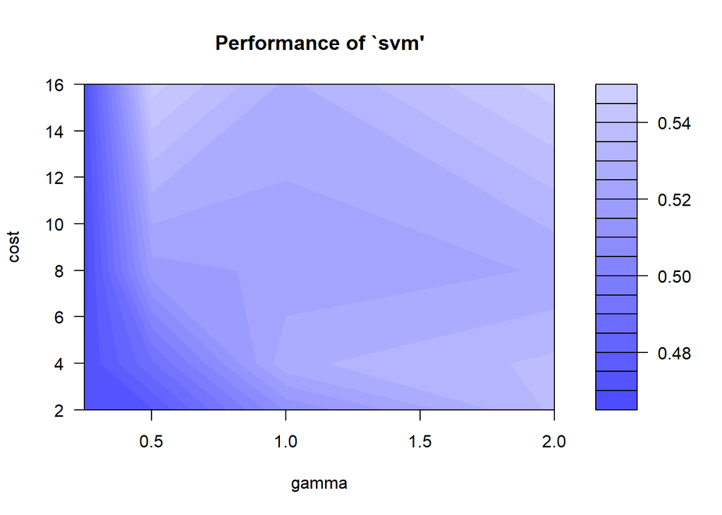

```r
plot(stockTuned)
```

```r
print(paste('best parameters: gamma=',stockTuned$best.parameters[1], ', cost=', stockTuned$best.parameters[2]))
```

```
## [1] "best parameters: gamma= 0.25 , cost= 8"
```

```r
#use optimized parameters...
model3 <- svm(XtrainSet, YtrainSet, gamma=as.numeric(stockTuned$best.parameters[1]), cost=as.numeric(stockTuned$best.parameters[2] ))
print(model3)
```

```
##
## Call:
## svm.default(x = XtrainSet, y = YtrainSet, gamma = as.numeric(stockTuned$best.parameters[1]),
##     cost = as.numeric(stockTuned$best.parameters[2]))
##
##
## Parameters:
##    SVM-Type:  C-classification
##  SVM-Kernel:  radial
##        cost:  8
##
## Number of Support Vectors:  230
```

```r
summary(model3)
```

```
##
## Call:
## svm.default(x = XtrainSet, y = YtrainSet, gamma = as.numeric(stockTuned$best.parameters[1]),
##     cost = as.numeric(stockTuned$best.parameters[2]))
##
##
## Parameters:
##    SVM-Type:  C-classification
##  SVM-Kernel:  radial
##        cost:  8
##
## Number of Support Vectors:  230
##
##  ( 97 61 72 )
##
##
## Number of Classes:  3
##
## Levels:
##  DOWN STABLE UP
```

```r
pred3 <- predict(model3, XtestSet)
# And the accuracy..
table(pred3, YtestSet)
```

```
##         YtestSet
## pred3    DOWN STABLE UP
##   DOWN      3      5  1
##   STABLE   12     41 14
##   UP        2      7  7
```

```r
XtestSetFortheMoney = NTDOYDataFrame[367:371,-6]
YtestSetFortheMoney  = NTDOYDataFrame[367:371,6]
pred4 <- predict(model3, XtestSetFortheMoney)
# And the accuracy..
print(pred4)
```

```
##    367    368    369    370    371
## STABLE STABLE STABLE STABLE STABLE
## Levels: DOWN STABLE UP
```

```r
#table(pred4, YtestSetFortheMoney)
```

```r
# compute decision values and probabilities:
pred <- predict(model3, XtestSet, decision.values = TRUE)
attr(pred, "decision.values")[1:6,]
```

```
##      STABLE/UP STABLE/DOWN    UP/DOWN
## 228 -0.2262904  -0.4094728 -0.9728749
## 173 -0.9229842  -0.7680457 -0.8851456
## 46   1.1072454   0.8990668 -1.1018040
## 287  1.0920051   1.2719065 -0.3615700
## 243 -1.0015553   0.5783457  0.5083538
## 101  0.9950096   1.1296245 -0.1289168
```

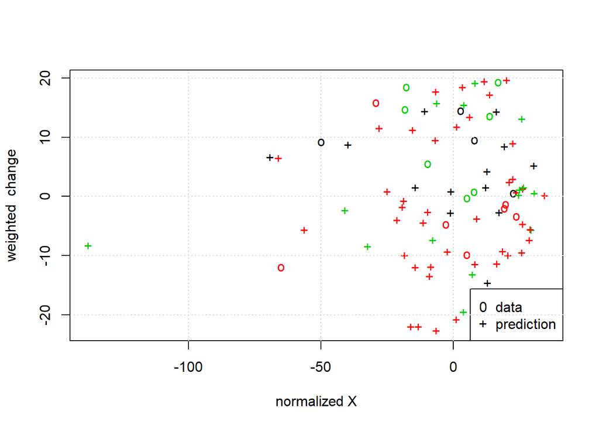

```r
# visualize (classes by color, SV by crosses):
plot(cmdscale(dist(XtestSet)),
     col = as.integer(YtestSet),xlab="normalized X", ylab = "weighted  change",
     pch = c("o","+")[1:150 %in% model3$index + 1])
legend('bottomright',c('data','prediction'),pch=c('0','+'))
grid()
```

# 3 SVM assignment

## 3.1 complete an rmarkdown file on the stock you selected.

You will turn in the URL for your github accout that has the repo for this assignment.

### 3.1.1 Identify the stock you use for this assignment.

Why did you choose this particular stock? Had lots of variability

### 3.1.2 Use this template to get the SVM:

1. Training and Test sets:

I used 75% of the data for the training set. I picked the testing data set by a random sample asssignment.

2. How well did the SVM do?

Did not do well..

3. Tune the algorithm- i.e. find optimal gamma and cost values.

tuned it, found optimal gamma and cost values, didn’t seem to help

### 3.1.3 Evaluate SVM performance

1. Did you exmine using other than the ‘open’, ‘low’, ‘high’, ‘close’ prices and volume as predictors?
2. Use the SVM you developed to predict stock moves on 16 - 20 Sept. 2019. Compute the ROI assuming the SVM identifies an opportunity, (for example use around $1000 on each of the SVM predictions)

3. Would you put your own $$ in this SVM?
   You gotta be kidding me..